# Testing affect regulation via computational modeling of real-time alcohol choices in daily life — Sensitivity Analyses: Alcohol Bias

### 4.3.4 Predicted vs. Observed

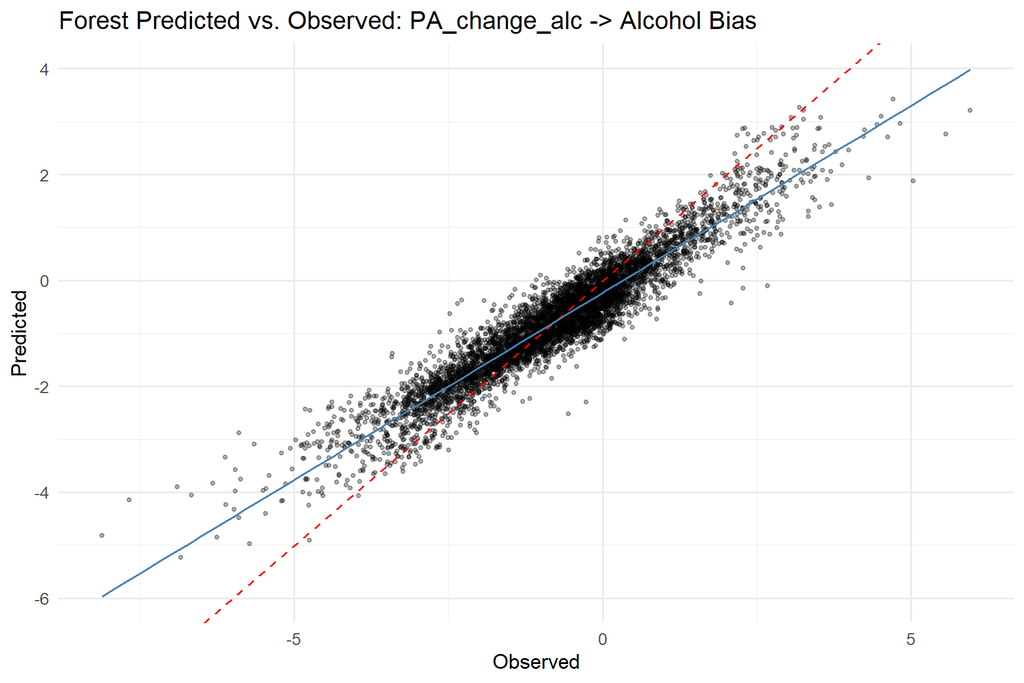

## 4.4 Model Comparison

### 4.4.1 RMSE Comparison (all methods and feature sets)

| Method | Raw | PCA | UMAP |
| --- | --- | --- | --- |
| glmm | 1.5432 | 1.7692 | 1.5997 |
| forest | 1.0402 | 1.2443 | 1.1502 |
| tree | 1.3237 | 1.3950 | 1.4070 |

# 5 Perceived Stress Change (vs. last assessment) (stress_state_change)

## 5.1 Dimensionality Reduction

- **PCA components (80% variance, max 5):** 5
- **UMAP components (matching PCA):** 5

### 5.1.1 PCA Component Composition (top 5 correlated variables)

**PC_1**

| Variable | Correlation |
| --- | --- |
| alc_exp_energeticYes | -0.576 |
| alc_exp_better_moodYes | -0.557 |
| alc_exp_sociableYes | -0.547 |
| alc_exp_buzzYes | -0.502 |
| alc_craving | -0.487 |

**PC_2**

| Variable | Correlation |
| --- | --- |
| alc_exp_injuryYes | -0.596 |
| alc_exp_be_rudeYes | -0.594 |
| alc_exp_embarrassedYes | -0.579 |
| alc_exp_nauseous_vomitYes | -0.491 |
| alc_exp_hangoverYes | -0.468 |

**PC_3**

| Variable | Correlation |
| --- | --- |
| locationschool_work | 0.591 |
| alc_today | -0.579 |
| alc_cuenone | 0.569 |
| time_of_dayevening | -0.476 |
| locationhome | -0.458 |

**PC_4**

| Variable | Correlation |
| --- | --- |
| soft_yday | 0.699 |
| soft_today | 0.651 |
| soft_intend | 0.635 |
| soft_craving | 0.489 |
| alc_exp_embarrassedYes | -0.388 |

**PC_5**

| Variable | Correlation |
| --- | --- |
| locationhome | -0.633 |
| social_context_aloneYes | -0.559 |
| social_context_friend_roommateYes | 0.500 |
| social_context_strangerYes | 0.418 |
| locationsomeone_elses_home | 0.371 |

### 5.1.2 UMAP Component Composition (top 5 correlated variables)

**UMAP_1**

| Variable | Correlation |
| --- | --- |
| alc_exp_embarrassedYes | 0.303 |
| alc_exp_be_rudeYes | 0.300 |
| alc_craving | 0.259 |
| alc_intend | 0.213 |
| alc_yday | 0.165 |

**UMAP_2**

| Variable | Correlation |
| --- | --- |
| alc_yday | -0.395 |
| alc_intend | -0.176 |
| soft_yday | 0.132 |
| alc_mot_enhanceYes | -0.124 |
| alc_exp_embarrassedYes | 0.120 |

**UMAP_3**

| Variable | Correlation |
| --- | --- |
| alc_today | -0.376 |
| alc_yday | -0.372 |
| alc_cuenone | 0.160 |
| alc_intend | -0.146 |
| social_context_familyYes | -0.132 |

**UMAP_4**

| Variable | Correlation |
| --- | --- |
| soft_yday | 0.779 |
| soft_today | 0.675 |
| soft_intend | 0.555 |
| soft_craving | 0.289 |
| alc_exp_injuryYes | 0.169 |

**UMAP_5**

| Variable | Correlation |
| --- | --- |
| alc_exp_injuryYes | 0.519 |
| alc_exp_embarrassedYes | 0.386 |
| alc_exp_be_rudeYes | 0.385 |
| alc_exp_nauseous_vomitYes | 0.365 |
| alc_exp_energeticYes | 0.230 |

## 5.2 GLMM Results

### 5.2.1 Raw Features

- **Optimal lambda:** 160 (index 5 of 21)
- **CV RMSE:** 1.6982

**Non-zero coefficients** (focal predictor terms highlighted):

| Term | Estimate | Category |
| --- | --- | --- |
| (Intercept) | -1.4505 | Intercept |
| alc_exp_nauseous_vomitYes | -0.5338 | Covariate main effect |
| alc_cuenone | -0.3117 | Covariate main effect |
| alc_craving | 0.3114 | Covariate main effect |
| alc_exp_relaxedYes | 0.2671 | Covariate main effect |
| alc_exp_injuryYes | -0.2130 | Covariate main effect |
| alc_mot_enhanceYes | 0.1993 | Covariate main effect |
| alc_exp_be_rudeYes | -0.1765 | Covariate main effect |
| social_context_strangerYes | 0.1684 | Covariate main effect |
| alc_exp_buzzYes | 0.1659 | Covariate main effect |
| time_of_dayevening | 0.1494 | Covariate main effect |
| alc_exp_embarrassedYes | -0.1480 | Covariate main effect |
| social_context_romantic_partnerYes | 0.1311 | Covariate main effect |
| alc_exp_better_moodYes | 0.1272 | Covariate main effect |
| locationother | 0.1254 | Covariate main effect |
| alc_exp_hangoverYes | -0.1176 | Covariate main effect |
| alc_intend | 0.1145 | Covariate main effect |
| social_context_familyYes | -0.1009 | Covariate main effect |
| social_context_coworker_classmateYes | -0.0907 | Covariate main effect |
| alc_today | 0.0867 | Covariate main effect |
| soft_intend | -0.0850 | Covariate main effect |
| soft_craving | -0.0716 | Covariate main effect |
| alc_mot_copingYes | 0.0647 | Covariate main effect |
| locationrestaurant_cafe | 0.0523 | Covariate main effect |
| bored_state | 0.0476 | Covariate main effect |
| alc_exp_sociableYes | 0.0371 | Covariate main effect |
| alc_yday | 0.0294 | Covariate main effect |
| responsibilityYes | 0.0277 | Covariate main effect |
| soft_yday | -0.0271 | Covariate main effect |
| thirst_state | 0.0246 | Covariate main effect |

[output cut: 52 more lines]

- 16 coefficients penalized to zero.*

#### 5.2.1.1 Predicted vs. Observed

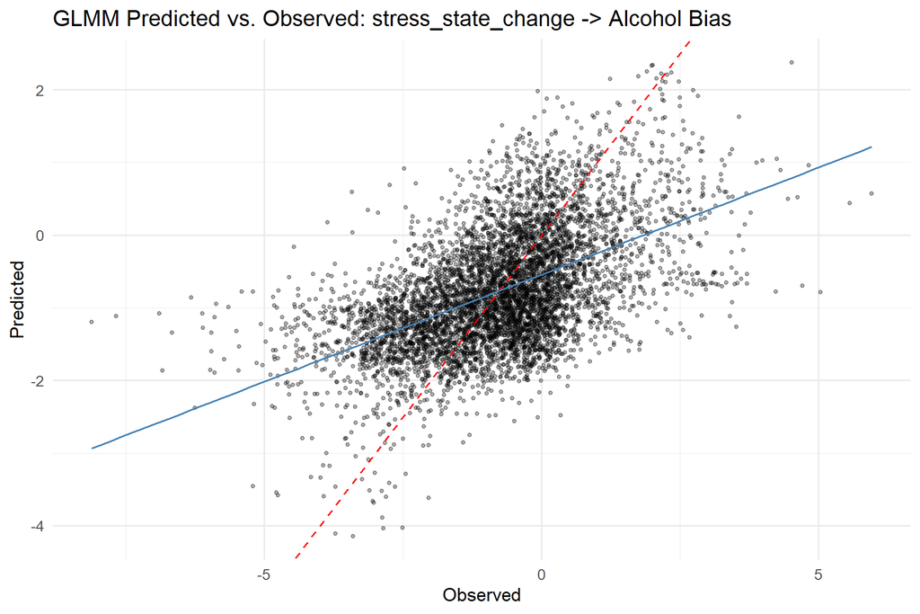

#### 5.2.1.2 Residual Diagnostics

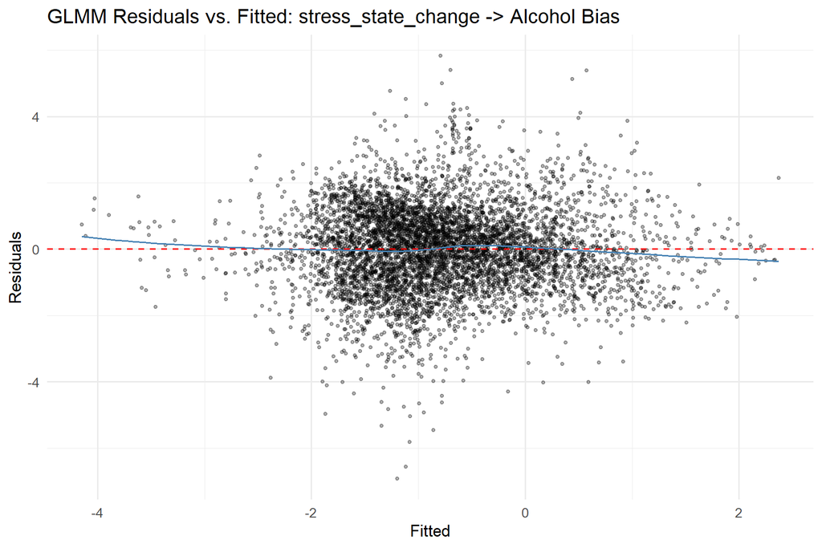

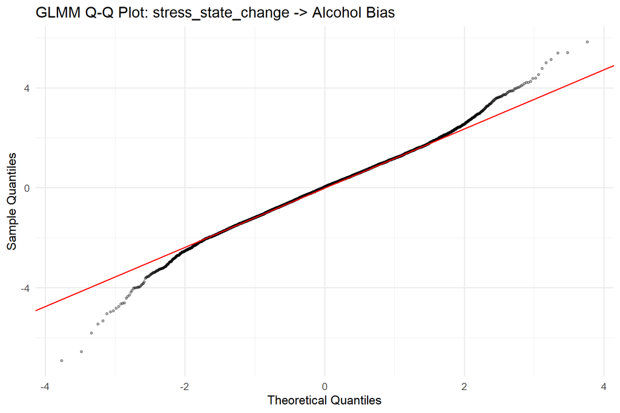

### 5.2.2 PCA Features

- **Optimal lambda:** 200 (index 1 of 21)
- **CV RMSE:** 1.7515

**Non-zero coefficients:**

| Term | Estimate |
| --- | --- |
| (Intercept) | -0.7529 |
| PC_1 | -0.2077 |
| PC_2 | 0.3583 |
| PC_3 | -0.3230 |
| PC_4 | 0.0094 |
| PC_5 | -0.0589 |
| stress_state_change | 0.0034 |
| PC_3:stress_state_change | 0.0164 |
| PC_4:stress_state_change | -0.0057 |
| PC_5:stress_state_change | 0.0054 |

- 2 coefficients penalized to zero.*

### 5.2.3 UMAP Features

- **Optimal lambda:** 190 (index 2 of 21)
- **CV RMSE:** 1.5709

**Non-zero coefficients:**

| Term | Estimate |
| --- | --- |
| (Intercept) | -0.7525 |
| UMAP_1 | 0.1379 |
| UMAP_2 | -0.0727 |
| UMAP_3 | -0.2221 |
| UMAP_4 | -0.2234 |
| UMAP_5 | -0.0005 |
| stress_state_change | 0.0114 |
| UMAP_1:stress_state_change | -0.0090 |
| UMAP_2:stress_state_change | 0.0053 |
| UMAP_3:stress_state_change | 0.0042 |
| UMAP_5:stress_state_change | 0.0046 |

- 1 coefficients penalized to zero.*

## 5.3 Random Forest Results (Raw)

### 5.3.1 Tuning Summary

- **mtry:** 18
- **min.node.size:** 2
- **sample.fraction:** 0.675
- **CV RMSE:** 1.0529

### 5.3.2 Variable Importance (Permutation)

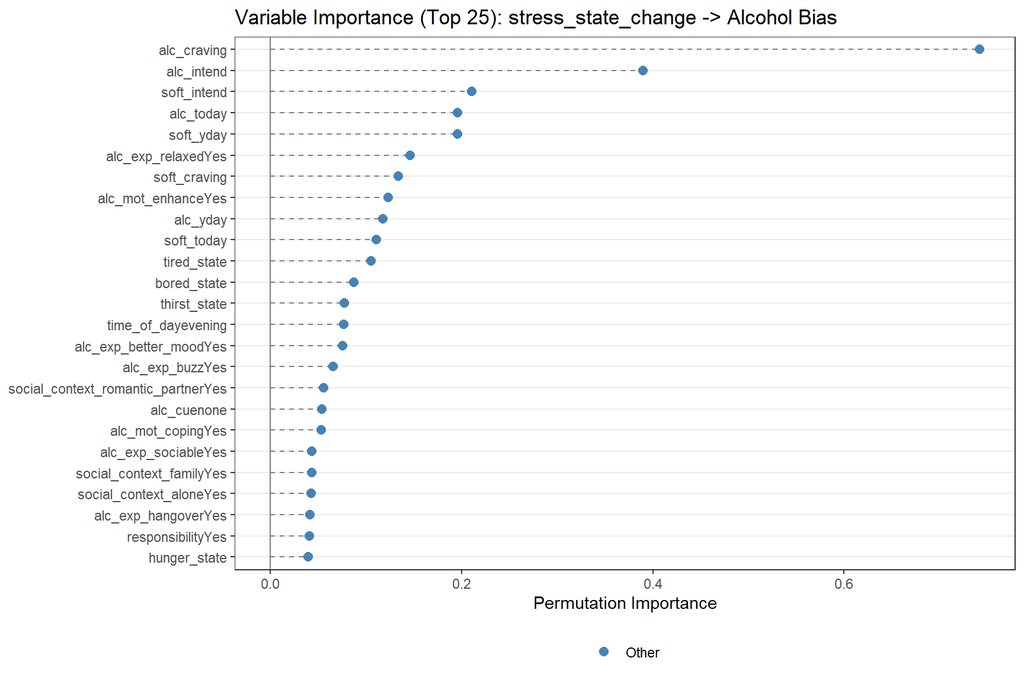

**Full importance ranking:**

| Variable | Importance |
| --- | --- |
| alc_craving | 0.741641 |
| alc_intend | 0.389585 |
| soft_intend | 0.210433 |
| alc_today | 0.195882 |
| soft_yday | 0.195826 |
| alc_exp_relaxedYes | 0.146056 |
| soft_craving | 0.133977 |
| alc_mot_enhanceYes | 0.123485 |
| alc_yday | 0.117852 |
| soft_today | 0.110753 |
| tired_state | 0.104978 |
| bored_state | 0.087413 |
| thirst_state | 0.077408 |
| time_of_dayevening | 0.076810 |
| alc_exp_better_moodYes | 0.075388 |
| alc_exp_buzzYes | 0.065324 |
| social_context_romantic_partnerYes | 0.055514 |
| alc_cuenone | 0.054109 |
| alc_mot_copingYes | 0.053074 |
| alc_exp_sociableYes | 0.043494 |
| social_context_familyYes | 0.043129 |
| social_context_aloneYes | 0.042860 |
| alc_exp_hangoverYes | 0.041527 |
| responsibilityYes | 0.040874 |
| hunger_state | 0.039479 |
| stress_state_change | 0.033628 |
| alc_exp_embarrassedYes | 0.024155 |
| alc_exp_nauseous_vomitYes | 0.017682 |
| locationhome | 0.017356 |
| alc_exp_energeticYes | 0.016819 |
| alc_exp_be_rudeYes | 0.016518 |
| alc_mot_socialYes | 0.011002 |
| locationschool_work | 0.009612 |
| alc_exp_injuryYes | 0.005876 |
| locationother | 0.003795 |
| social_context_friend_roommateYes | 0.002880 |
| day_of_weekSat | 0.002037 |
| social_context_coworker_classmateYes | 0.001511 |
| locationsomeone_elses_home | 0.001201 |
| social_context_strangerYes | 0.000819 |
| locationoutdoors | 0.000726 |
| alc_cueindirectly_visible | 0.000543 |
| social_context_otherYes | 0.000184 |
| locationrestaurant_cafe | 0.000078 |
| day_of_weekSun | -0.001443 |
| day_of_weekMon | -0.001504 |
| day_of_weekWed | -0.002978 |
| day_of_weekTue | -0.003735 |
| day_of_weekThu | -0.004029 |

### 5.3.3 Partial Dependence Plots

PDP for the focal predictor and the top 5 most important non-interaction covariates.

#### 5.3.3.1 Focal Predictor: stress_state_change

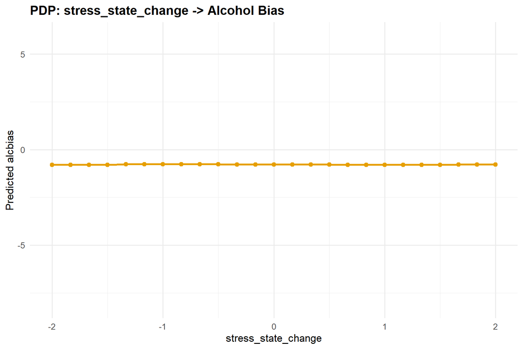

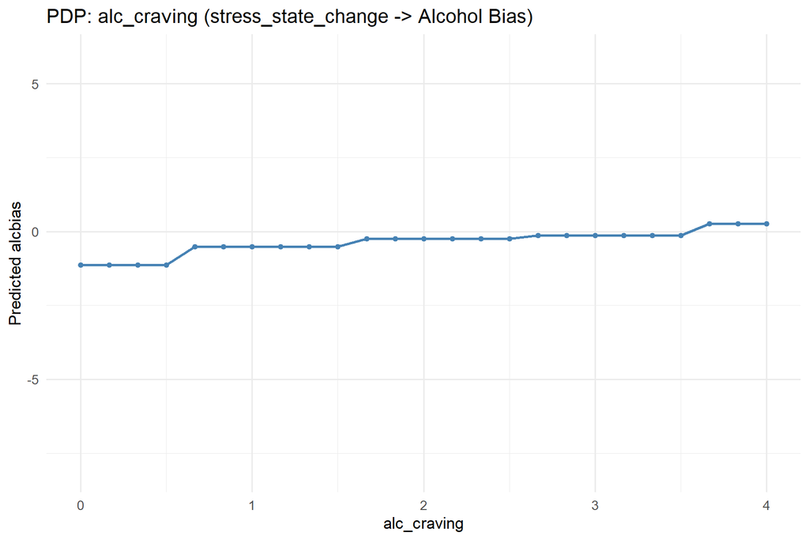

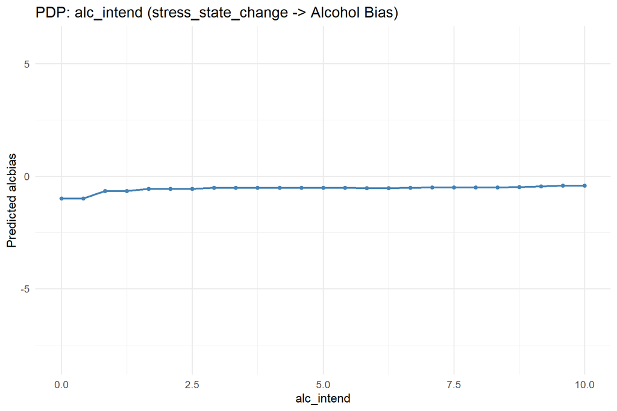

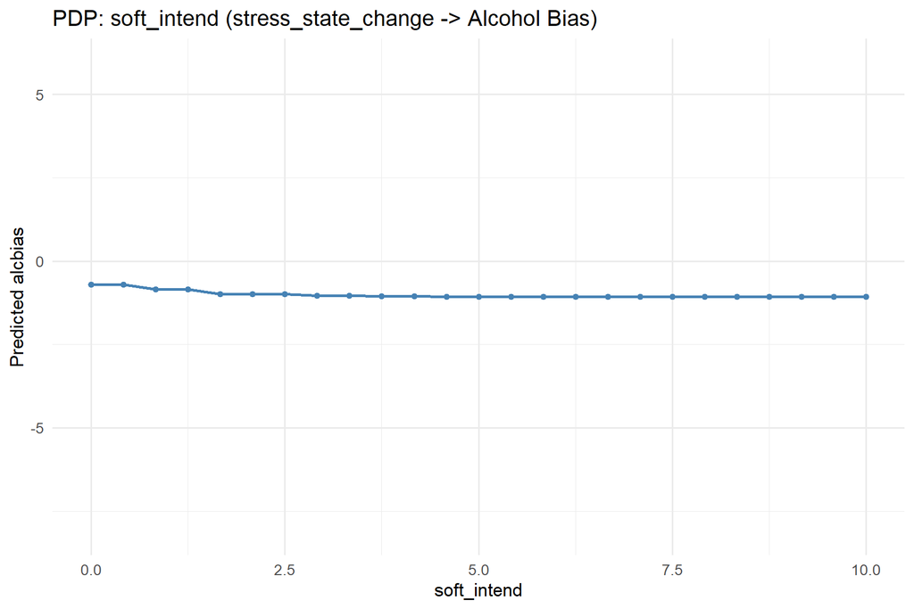

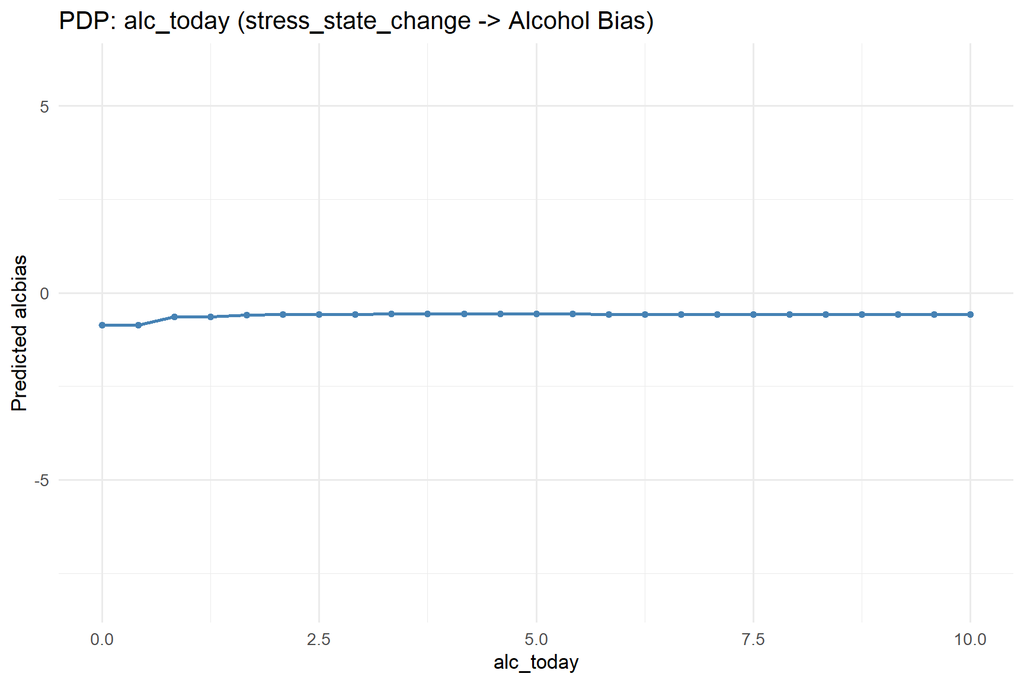

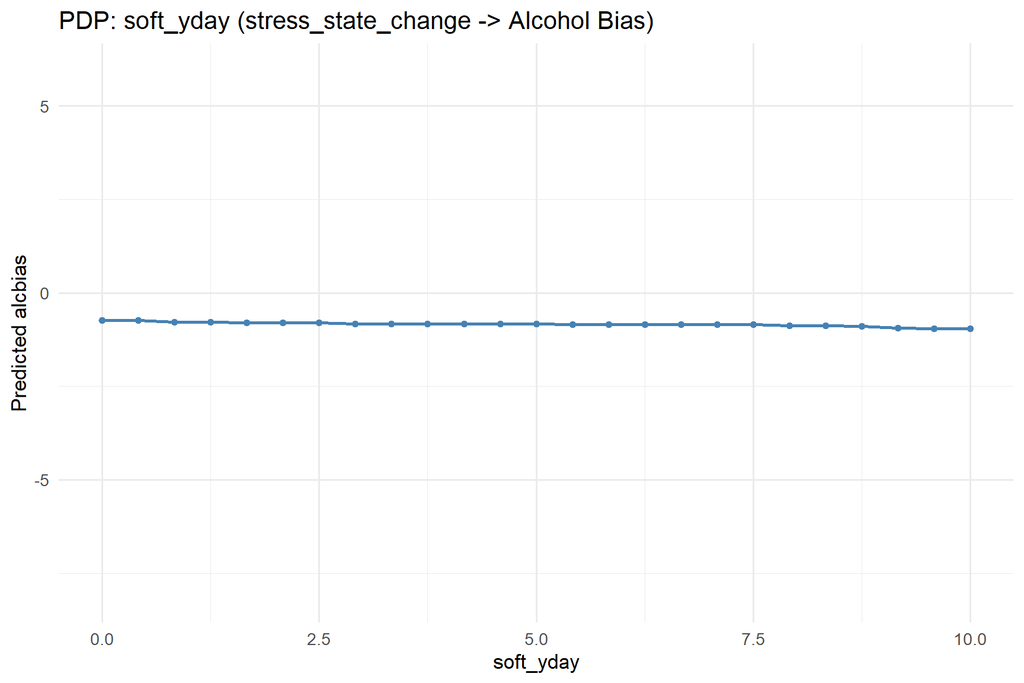

### 5.3.4 Predicted vs. Observed

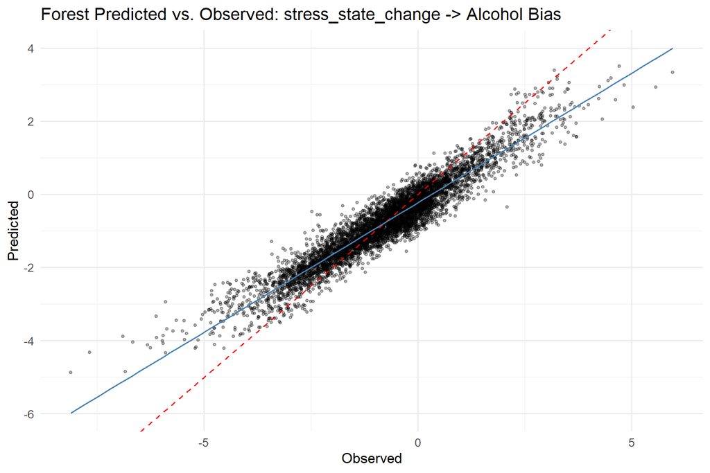

## 5.4 Model Comparison

### 5.4.1 RMSE Comparison (all methods and feature sets)

| Method | Raw | PCA | UMAP |
| --- | --- | --- | --- |
| glmm | 1.6982 | 1.7515 | 1.5709 |
| forest | 1.0529 | 1.2686 | 1.1806 |
| tree | 1.3462 | 1.4088 | 1.4227 |

# 6 Perceived Negative Affect Change (vs. last assessment) (NA_state_change)

## 6.1 Dimensionality Reduction

- **PCA components (80% variance, max 5):** 5
- **UMAP components (matching PCA):** 5

### 6.1.1 PCA Component Composition (top 5 correlated variables)

**PC_1**

| Variable | Correlation |
| --- | --- |
| alc_exp_energeticYes | -0.576 |
| alc_exp_better_moodYes | -0.557 |
| alc_exp_sociableYes | -0.547 |
| alc_exp_buzzYes | -0.503 |
| alc_craving | -0.487 |

**PC_2**

| Variable | Correlation |
| --- | --- |
| alc_exp_injuryYes | -0.596 |
| alc_exp_be_rudeYes | -0.594 |
| alc_exp_embarrassedYes | -0.579 |
| alc_exp_nauseous_vomitYes | -0.491 |
| alc_exp_hangoverYes | -0.468 |

**PC_3**

| Variable | Correlation |
| --- | --- |
| locationschool_work | 0.591 |
| alc_today | -0.578 |
| alc_cuenone | 0.569 |
| time_of_dayevening | -0.476 |
| locationhome | -0.458 |

**PC_4**

| Variable | Correlation |
| --- | --- |
| soft_yday | 0.699 |
| soft_today | 0.650 |
| soft_intend | 0.634 |
| soft_craving | 0.488 |
| alc_exp_embarrassedYes | -0.388 |

**PC_5**

| Variable | Correlation |
| --- | --- |
| locationhome | -0.632 |
| social_context_aloneYes | -0.560 |
| social_context_friend_roommateYes | 0.500 |
| social_context_strangerYes | 0.417 |
| locationsomeone_elses_home | 0.371 |

### 6.1.2 UMAP Component Composition (top 5 correlated variables)

**UMAP_1**

| Variable | Correlation |
| --- | --- |
| alc_exp_embarrassedYes | -0.301 |
| alc_exp_be_rudeYes | -0.299 |
| alc_craving | -0.245 |
| alc_intend | -0.208 |
| alc_yday | -0.179 |

**UMAP_2**

| Variable | Correlation |
| --- | --- |
| alc_yday | 0.369 |
| alc_intend | 0.148 |
| alc_mot_enhanceYes | 0.118 |
| alc_exp_embarrassedYes | -0.091 |
| alc_exp_hangoverYes | 0.089 |

**UMAP_3**

| Variable | Correlation |
| --- | --- |
| alc_today | 0.415 |
| alc_yday | 0.389 |
| alc_cuenone | -0.181 |
| alc_intend | 0.168 |
| soft_craving | -0.156 |

**UMAP_4**

| Variable | Correlation |
| --- | --- |
| soft_yday | -0.788 |
| soft_today | -0.679 |
| soft_intend | -0.558 |
| soft_craving | -0.295 |
| alc_exp_injuryYes | -0.194 |

**UMAP_5**

| Variable | Correlation |
| --- | --- |
| alc_exp_injuryYes | -0.517 |
| alc_exp_embarrassedYes | -0.389 |
| alc_exp_be_rudeYes | -0.387 |
| alc_exp_nauseous_vomitYes | -0.364 |
| alc_exp_energeticYes | -0.227 |

## 6.2 GLMM Results

### 6.2.1 Raw Features

- **Optimal lambda:** 200 (index 1 of 21)
- **CV RMSE:** 1.6887

**Non-zero coefficients** (focal predictor terms highlighted):

| Term | Estimate | Category |
| --- | --- | --- |
| (Intercept) | -1.3881 | Intercept |
| NA_state_change | -0.0001 | Focal predictor |
| alc_exp_nauseous_vomitYes | -0.5063 | Covariate main effect |
| alc_craving | 0.3127 | Covariate main effect |
| alc_cuenone | -0.2882 | Covariate main effect |
| alc_exp_relaxedYes | 0.2456 | Covariate main effect |
| alc_mot_enhanceYes | 0.1781 | Covariate main effect |
| alc_exp_injuryYes | -0.1550 | Covariate main effect |
| alc_exp_be_rudeYes | -0.1482 | Covariate main effect |
| alc_exp_buzzYes | 0.1448 | Covariate main effect |
| time_of_dayevening | 0.1419 | Covariate main effect |
| social_context_strangerYes | 0.1400 | Covariate main effect |
| social_context_romantic_partnerYes | 0.1210 | Covariate main effect |
| locationother | 0.1173 | Covariate main effect |
| alc_exp_embarrassedYes | -0.1158 | Covariate main effect |
| alc_intend | 0.1089 | Covariate main effect |
| social_context_familyYes | -0.0980 | Covariate main effect |
| alc_exp_better_moodYes | 0.0965 | Covariate main effect |
| alc_exp_hangoverYes | -0.0923 | Covariate main effect |
| soft_intend | -0.0845 | Covariate main effect |
| alc_today | 0.0804 | Covariate main effect |
| social_context_coworker_classmateYes | -0.0716 | Covariate main effect |
| soft_craving | -0.0653 | Covariate main effect |
| bored_state | 0.0402 | Covariate main effect |
| alc_mot_copingYes | 0.0298 | Covariate main effect |
| responsibilityYes | 0.0249 | Covariate main effect |
| soft_yday | -0.0242 | Covariate main effect |
| alc_yday | 0.0235 | Covariate main effect |
| thirst_state | 0.0161 | Covariate main effect |
| alc_exp_sociableYes | 0.0137 | Covariate main effect |

[output cut: 54 more lines]

- 14 coefficients penalized to zero.*

#### 6.2.1.1 Predicted vs. Observed

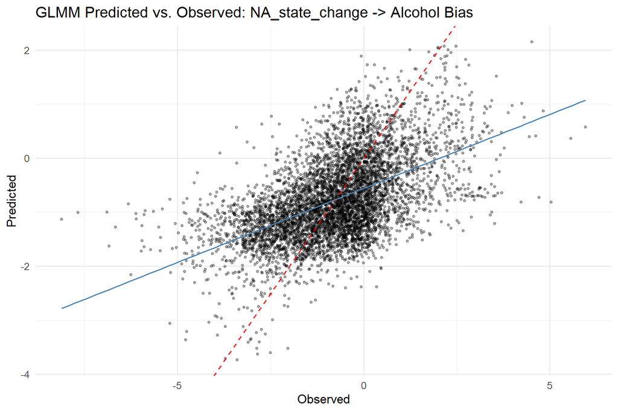

#### 6.2.1.2 Residual Diagnostics

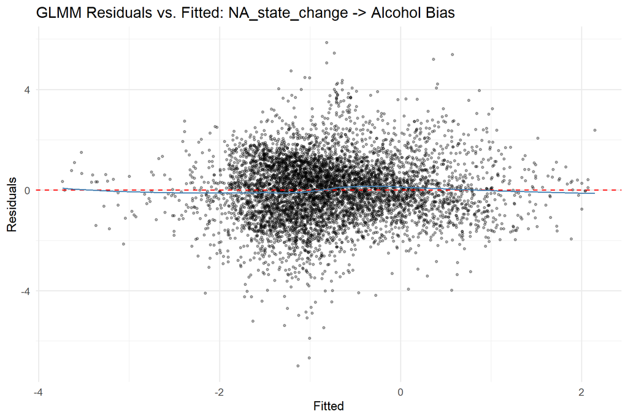

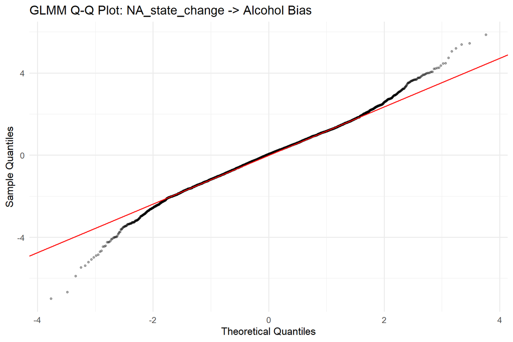

### 6.2.2 PCA Features

- **Optimal lambda:** 190 (index 2 of 21)
- **CV RMSE:** 1.7577

**Non-zero coefficients:**

| Term | Estimate |
| --- | --- |
| (Intercept) | -0.7660 |
| PC_1 | -0.2259 |
| PC_2 | 0.4110 |
| PC_3 | -0.3424 |
| PC_4 | 0.0162 |
| PC_5 | -0.0847 |
| NA_state_change | 0.0493 |
| PC_3:NA_state_change | 0.0080 |
| PC_5:NA_state_change | -0.0110 |

- 3 coefficients penalized to zero.*

### 6.2.3 UMAP Features

- **Optimal lambda:** 200 (index 1 of 21)
- **CV RMSE:** 1.603

**Non-zero coefficients:**

| Term | Estimate |
| --- | --- |
| (Intercept) | -0.7565 |
| UMAP_1 | -0.0861 |
| UMAP_2 | 0.0500 |
| UMAP_3 | 0.1950 |
| UMAP_4 | 0.2332 |
| NA_state_change | 0.0087 |
| UMAP_1:NA_state_change | 0.0243 |
| UMAP_4:NA_state_change | 0.0016 |
| UMAP_5:NA_state_change | 0.0104 |

- 3 coefficients penalized to zero.*

## 6.3 Random Forest Results (Raw)

### 6.3.1 Tuning Summary

- **mtry:** 18
- **min.node.size:** 2
- **sample.fraction:** 0.701
- **CV RMSE:** 1.0546

### 6.3.2 Variable Importance (Permutation)

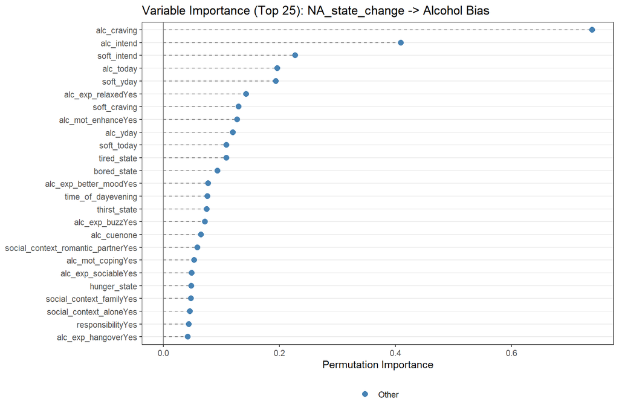

**Full importance ranking:**

| Variable | Importance |
| --- | --- |
| alc_craving | 0.739123 |
| alc_intend | 0.409471 |
| soft_intend | 0.227431 |
| alc_today | 0.196423 |
| soft_yday | 0.194036 |
| alc_exp_relaxedYes | 0.142726 |
| soft_craving | 0.129519 |
| alc_mot_enhanceYes | 0.127032 |
| alc_yday | 0.119789 |
| soft_today | 0.108782 |
| tired_state | 0.108493 |
| bored_state | 0.093229 |
| alc_exp_better_moodYes | 0.076935 |
| time_of_dayevening | 0.075608 |
| thirst_state | 0.074482 |
| alc_exp_buzzYes | 0.071307 |
| alc_cuenone | 0.064569 |
| social_context_romantic_partnerYes | 0.058449 |
| alc_mot_copingYes | 0.052852 |
| alc_exp_sociableYes | 0.048506 |
| hunger_state | 0.047995 |
| social_context_familyYes | 0.047686 |
| social_context_aloneYes | 0.045450 |
| responsibilityYes | 0.043563 |
| alc_exp_hangoverYes | 0.041865 |
| NA_state_change | 0.031645 |
| alc_exp_embarrassedYes | 0.024961 |
| alc_exp_nauseous_vomitYes | 0.018723 |
| alc_exp_energeticYes | 0.016179 |
| locationhome | 0.015521 |
| alc_exp_be_rudeYes | 0.015414 |
| alc_mot_socialYes | 0.012305 |
| locationschool_work | 0.011219 |
| alc_exp_injuryYes | 0.004870 |
| locationother | 0.003656 |
| social_context_friend_roommateYes | 0.003115 |
| social_context_coworker_classmateYes | 0.001745 |
| locationsomeone_elses_home | 0.001557 |
| day_of_weekSat | 0.001456 |
| alc_cueindirectly_visible | 0.000803 |
| locationoutdoors | 0.000592 |
| social_context_strangerYes | 0.000380 |
| social_context_otherYes | 0.000285 |
| locationrestaurant_cafe | 0.000098 |
| day_of_weekSun | -0.000482 |
| day_of_weekMon | -0.000921 |
| day_of_weekTue | -0.001377 |
| day_of_weekThu | -0.001513 |
| day_of_weekWed | -0.003741 |

### 6.3.3 Partial Dependence Plots

PDP for the focal predictor and the top 5 most important non-interaction covariates.

#### 6.3.3.1 Focal Predictor: NA_state_change

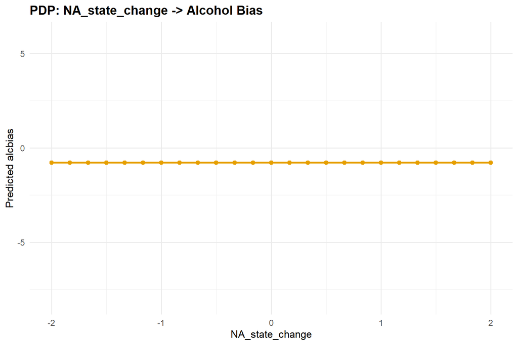

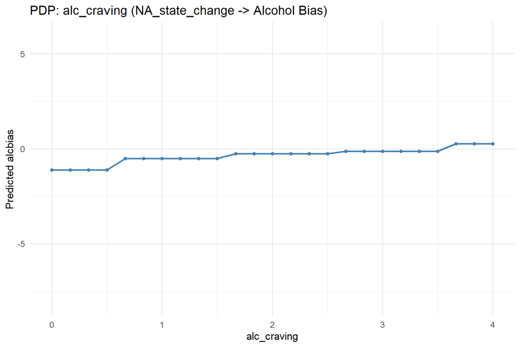

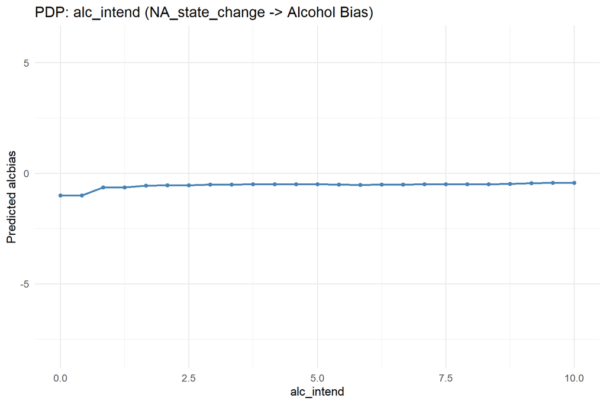

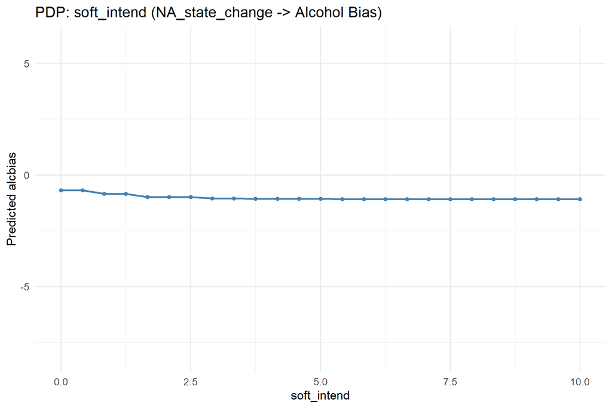

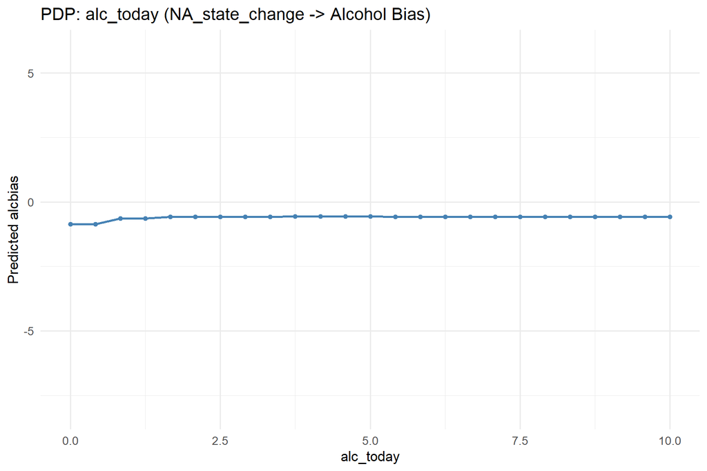

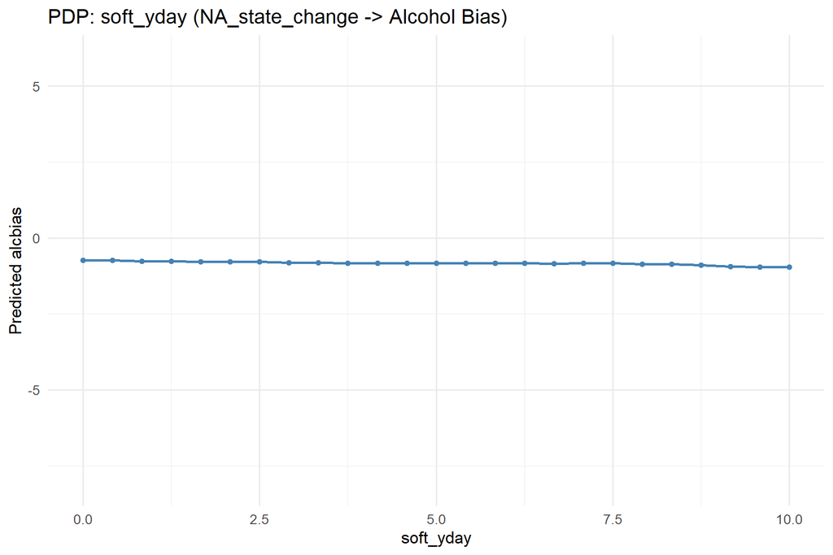

### 6.3.4 Predicted vs. Observed

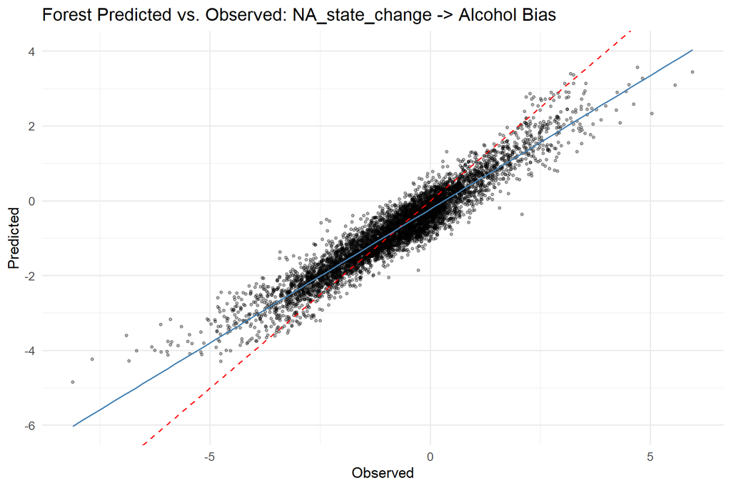

## 6.4 Model Comparison

### 6.4.1 RMSE Comparison (all methods and feature sets)

| Method | Raw | PCA | UMAP |
| --- | --- | --- | --- |
| glmm | 1.6887 | 1.7577 | 1.6030 |
| forest | 1.0546 | 1.2696 | 1.1821 |
| tree | 1.3482 | 1.4188 | 1.4264 |

# 7 Perceived Positive Affect Change (vs. last assessment) (PA_state_change)

## 7.1 Dimensionality Reduction

- **PCA components (80% variance, max 5):** 5
- **UMAP components (matching PCA):** 5

### 7.1.1 PCA Component Composition (top 5 correlated variables)

**PC_1**

| Variable | Correlation |
| --- | --- |
| alc_exp_energeticYes | -0.576 |
| alc_exp_better_moodYes | -0.557 |
| alc_exp_sociableYes | -0.547 |
| alc_exp_buzzYes | -0.502 |
| alc_craving | -0.487 |

**PC_2**

| Variable | Correlation |
| --- | --- |
| alc_exp_injuryYes | -0.595 |
| alc_exp_be_rudeYes | -0.593 |
| alc_exp_embarrassedYes | -0.578 |
| alc_exp_nauseous_vomitYes | -0.491 |
| alc_exp_hangoverYes | -0.468 |

**PC_3**

| Variable | Correlation |
| --- | --- |
| locationschool_work | 0.590 |
| alc_today | -0.578 |
| alc_cuenone | 0.568 |
| time_of_dayevening | -0.476 |
| locationhome | -0.457 |

**PC_4**

| Variable | Correlation |
| --- | --- |
| soft_yday | 0.699 |
| soft_today | 0.650 |
| soft_intend | 0.633 |
| soft_craving | 0.488 |
| alc_exp_embarrassedYes | -0.389 |

**PC_5**

| Variable | Correlation |
| --- | --- |
| locationhome | -0.633 |
| social_context_aloneYes | -0.560 |
| social_context_friend_roommateYes | 0.500 |
| social_context_strangerYes | 0.417 |
| locationsomeone_elses_home | 0.371 |

### 7.1.2 UMAP Component Composition (top 5 correlated variables)

**UMAP_1**

| Variable | Correlation |
| --- | --- |
| alc_exp_embarrassedYes | 0.284 |
| alc_exp_be_rudeYes | 0.281 |
| alc_craving | 0.223 |
| alc_intend | 0.195 |
| alc_yday | 0.189 |

**UMAP_2**

| Variable | Correlation |
| --- | --- |
| alc_yday | -0.334 |
| alc_exp_embarrassedYes | 0.150 |
| alc_exp_be_rudeYes | 0.147 |
| alc_intend | -0.145 |
| alc_mot_enhanceYes | -0.122 |

**UMAP_3**

| Variable | Correlation |
| --- | --- |
| alc_today | -0.408 |
| alc_yday | -0.398 |
| alc_cuenone | 0.176 |
| alc_intend | -0.154 |
| soft_craving | 0.138 |

**UMAP_4**

| Variable | Correlation |
| --- | --- |
| soft_yday | 0.797 |
| soft_today | 0.687 |
| soft_intend | 0.569 |
| soft_craving | 0.299 |
| alc_exp_be_rudeYes | 0.165 |

**UMAP_5**

| Variable | Correlation |
| --- | --- |
| alc_exp_injuryYes | 0.516 |
| alc_exp_embarrassedYes | 0.389 |
| alc_exp_be_rudeYes | 0.386 |
| alc_exp_nauseous_vomitYes | 0.358 |
| alc_exp_energeticYes | 0.231 |

## 7.2 GLMM Results

### 7.2.1 Raw Features

- **Optimal lambda:** 190 (index 2 of 21)
- **CV RMSE:** 1.6965

**Non-zero coefficients** (focal predictor terms highlighted):

| Term | Estimate | Category |
| --- | --- | --- |
| (Intercept) | -1.3622 | Intercept |
| PA_state_change | -0.0001 | Focal predictor |
| alc_exp_nauseous_vomitYes | -0.4959 | Covariate main effect |
| alc_craving | 0.3195 | Covariate main effect |
| alc_cuenone | -0.2674 | Covariate main effect |
| alc_exp_relaxedYes | 0.2318 | Covariate main effect |
| alc_mot_enhanceYes | 0.1621 | Covariate main effect |
| social_context_strangerYes | 0.1455 | Covariate main effect |
| time_of_dayevening | 0.1392 | Covariate main effect |
| alc_exp_be_rudeYes | -0.1366 | Covariate main effect |
| alc_exp_buzzYes | 0.1317 | Covariate main effect |
| social_context_romantic_partnerYes | 0.1282 | Covariate main effect |
| locationother | 0.1247 | Covariate main effect |
| alc_exp_embarrassedYes | -0.1074 | Covariate main effect |
| alc_intend | 0.1056 | Covariate main effect |
| alc_exp_injuryYes | -0.0997 | Covariate main effect |
| social_context_familyYes | -0.0991 | Covariate main effect |
| soft_intend | -0.0856 | Covariate main effect |
| alc_exp_hangoverYes | -0.0829 | Covariate main effect |
| alc_today | 0.0755 | Covariate main effect |
| alc_exp_better_moodYes | 0.0679 | Covariate main effect |
| social_context_coworker_classmateYes | -0.0654 | Covariate main effect |
| soft_craving | -0.0634 | Covariate main effect |
| bored_state | 0.0420 | Covariate main effect |
| responsibilityYes | 0.0314 | Covariate main effect |
| soft_yday | -0.0227 | Covariate main effect |
| locationoutdoors | 0.0210 | Covariate main effect |
| alc_yday | 0.0192 | Covariate main effect |
| thirst_state | 0.0151 | Covariate main effect |
| alc_exp_energeticYes | -0.0145 | Covariate main effect |

[output cut: 58 more lines]

- 10 coefficients penalized to zero.*

#### 7.2.1.1 Predicted vs. Observed

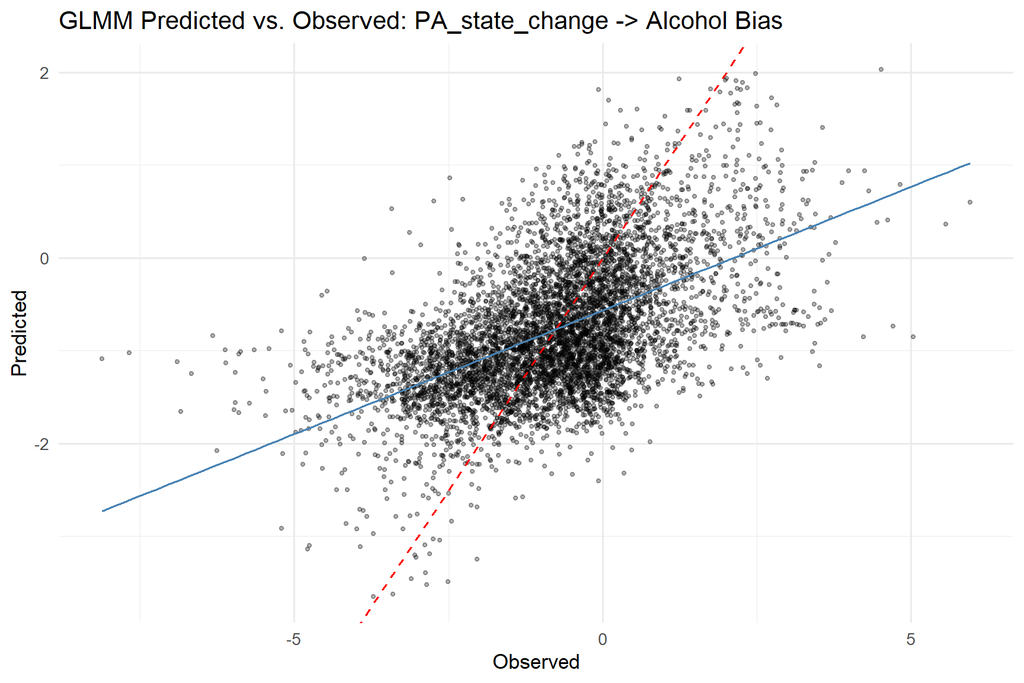

#### 7.2.1.2 Residual Diagnostics

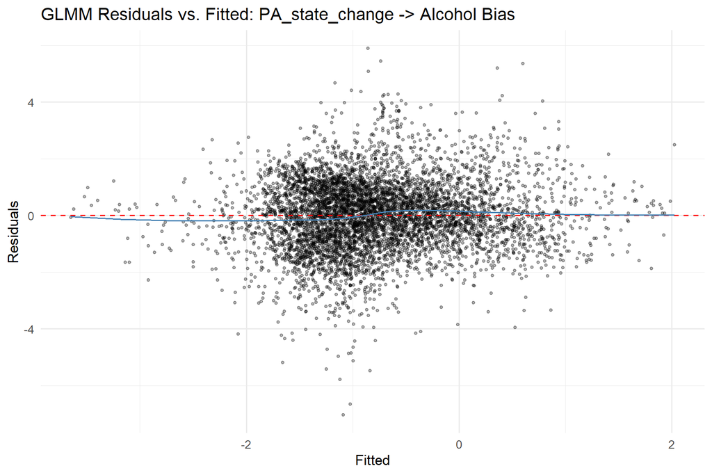

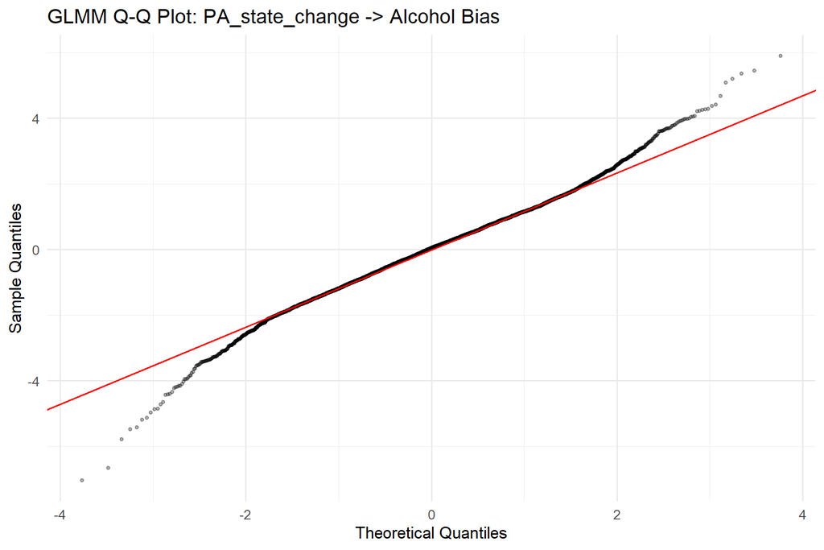

### 7.2.2 PCA Features

- **Optimal lambda:** 200 (index 1 of 21)
- **CV RMSE:** 1.729

**Non-zero coefficients:**

| Term | Estimate |
| --- | --- |
| (Intercept) | -0.7564 |
| PC_1 | -0.2180 |
| PC_2 | 0.3928 |
| PC_3 | -0.3364 |
| PC_4 | 0.0165 |
| PC_5 | -0.0699 |
| PA_state_change | -0.0446 |
| PC_1:PA_state_change | -0.0008 |
| PC_3:PA_state_change | -0.0056 |
| PC_5:PA_state_change | -0.0027 |

- 2 coefficients penalized to zero.*

### 7.2.3 UMAP Features

- **Optimal lambda:** 190 (index 2 of 21)
- **CV RMSE:** 1.5805

**Non-zero coefficients:**

| Term | Estimate |
| --- | --- |
| (Intercept) | -0.7547 |
| UMAP_1 | 0.1110 |
| UMAP_2 | -0.0571 |
| UMAP_3 | -0.2007 |
| UMAP_4 | -0.1917 |
| PA_state_change | -0.0088 |
| UMAP_1:PA_state_change | 0.0118 |
| UMAP_2:PA_state_change | -0.0013 |
| UMAP_3:PA_state_change | -0.0036 |
| UMAP_5:PA_state_change | -0.0165 |

- 2 coefficients penalized to zero.*

## 7.3 Random Forest Results (Raw)

### 7.3.1 Tuning Summary

- **mtry:** 20
- **min.node.size:** 2
- **sample.fraction:** 0.729
- **CV RMSE:** 1.0544

### 7.3.2 Variable Importance (Permutation)

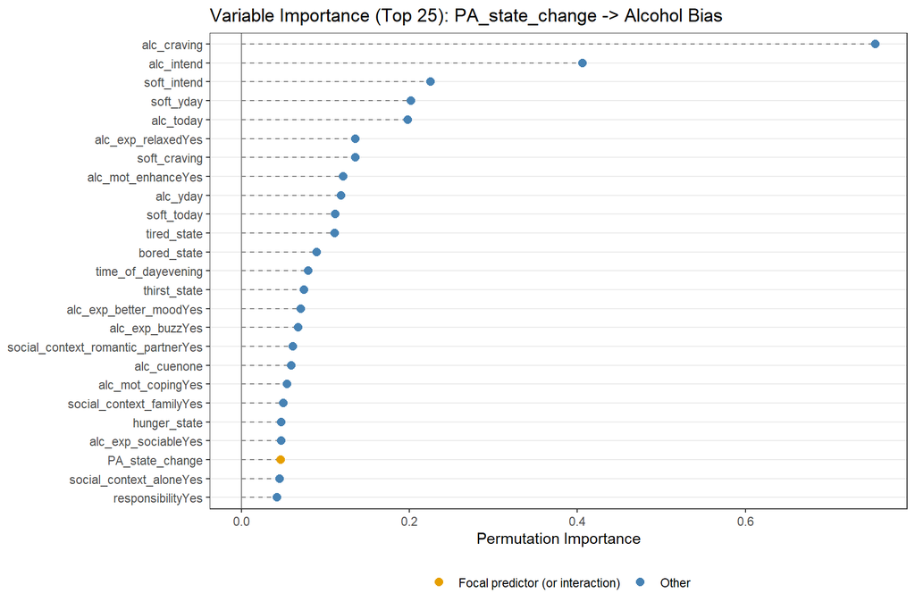

**Full importance ranking:**

| Variable | Importance |
| --- | --- |
| alc_craving | 0.754802 |
| alc_intend | 0.405995 |
| soft_intend | 0.225239 |
| soft_yday | 0.201748 |
| alc_today | 0.197987 |
| alc_exp_relaxedYes | 0.135214 |
| soft_craving | 0.135204 |
| alc_mot_enhanceYes | 0.120812 |
| alc_yday | 0.118755 |
| soft_today | 0.111581 |
| tired_state | 0.111093 |
| bored_state | 0.089226 |
| time_of_dayevening | 0.079104 |
| thirst_state | 0.074147 |
| alc_exp_better_moodYes | 0.070481 |
| alc_exp_buzzYes | 0.067527 |
| social_context_romantic_partnerYes | 0.060946 |
| alc_cuenone | 0.059490 |
| alc_mot_copingYes | 0.054413 |
| social_context_familyYes | 0.049901 |
| hunger_state | 0.047381 |
| alc_exp_sociableYes | 0.047335 |
| PA_state_change | 0.046633 |
| social_context_aloneYes | 0.045378 |
| responsibilityYes | 0.042412 |
| alc_exp_hangoverYes | 0.041417 |
| alc_exp_embarrassedYes | 0.027174 |
| alc_exp_nauseous_vomitYes | 0.017486 |
| locationhome | 0.017134 |
| alc_exp_be_rudeYes | 0.017114 |
| alc_exp_energeticYes | 0.016449 |
| alc_mot_socialYes | 0.012083 |
| locationschool_work | 0.009837 |
| alc_exp_injuryYes | 0.005721 |
| locationother | 0.004214 |
| social_context_friend_roommateYes | 0.002977 |
| day_of_weekSat | 0.001499 |
| social_context_coworker_classmateYes | 0.001251 |
| alc_cueindirectly_visible | 0.000810 |
| locationsomeone_elses_home | 0.000784 |
| locationoutdoors | 0.000198 |
| locationrestaurant_cafe | 0.000152 |
| social_context_otherYes | 0.000110 |
| social_context_strangerYes | -0.000076 |
| day_of_weekSun | -0.000246 |
| day_of_weekWed | -0.001211 |
| day_of_weekMon | -0.001662 |
| day_of_weekThu | -0.003435 |
| day_of_weekTue | -0.003777 |

### 7.3.3 Partial Dependence Plots

PDP for the focal predictor and the top 5 most important non-interaction covariates.

#### 7.3.3.1 Focal Predictor: PA_state_change

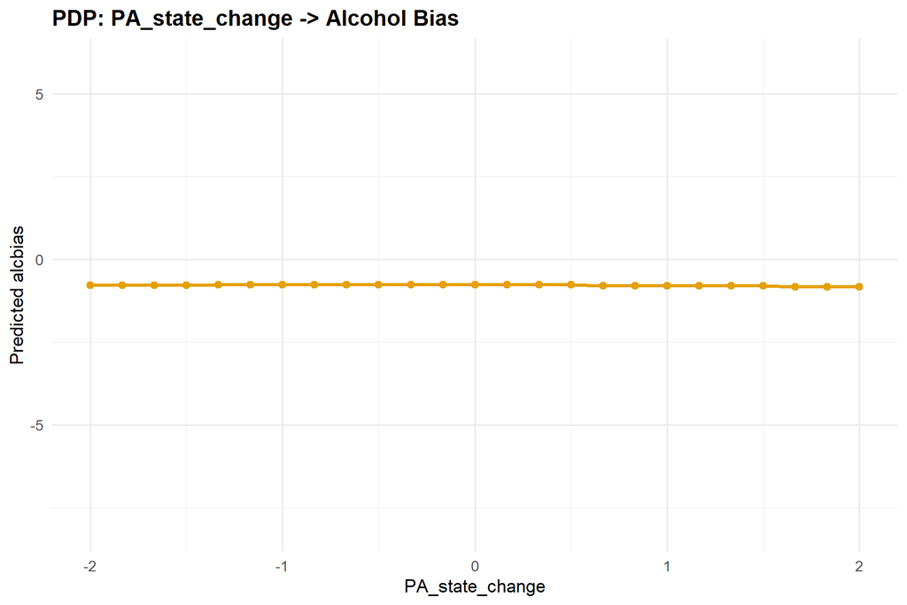

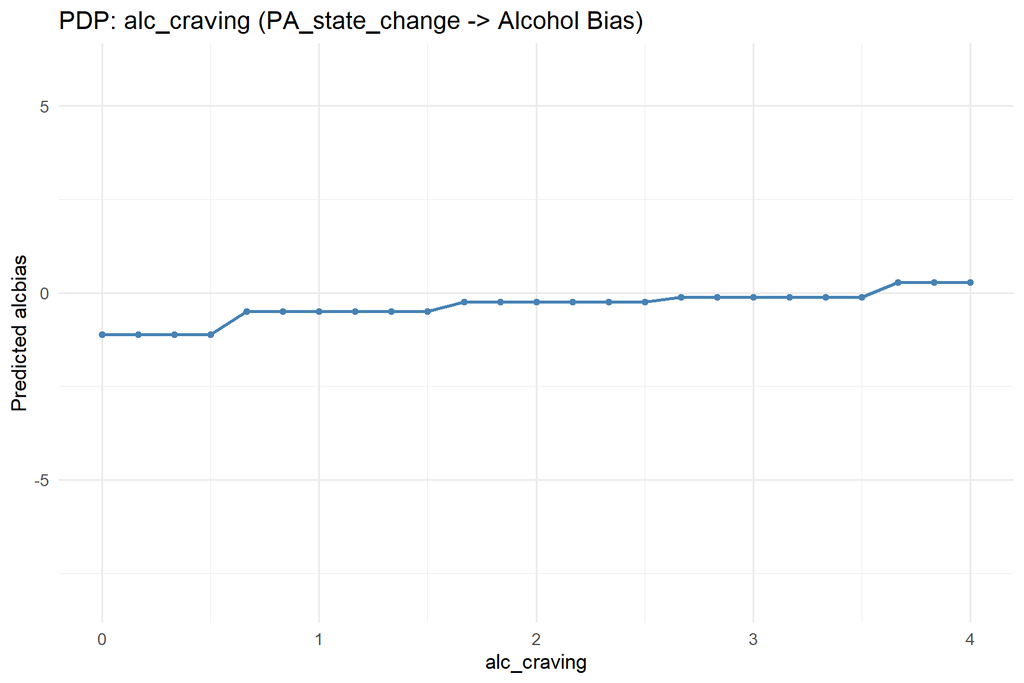

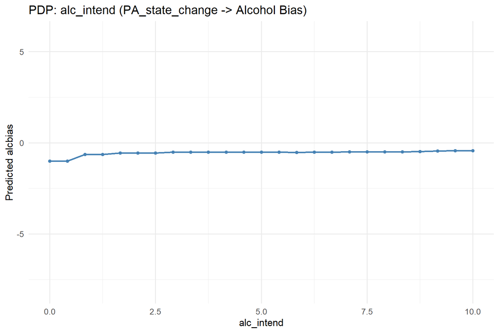

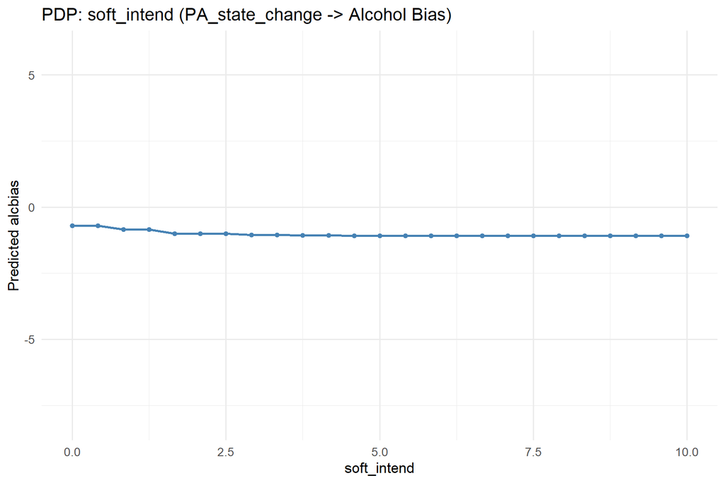

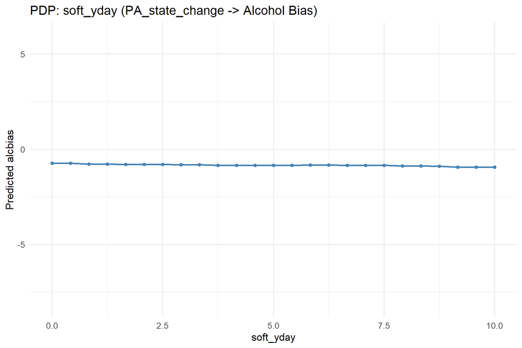

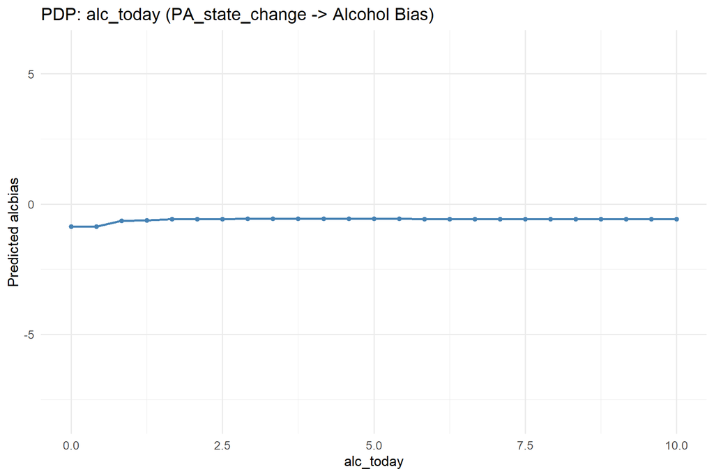

### 7.3.4 Predicted vs. Observed

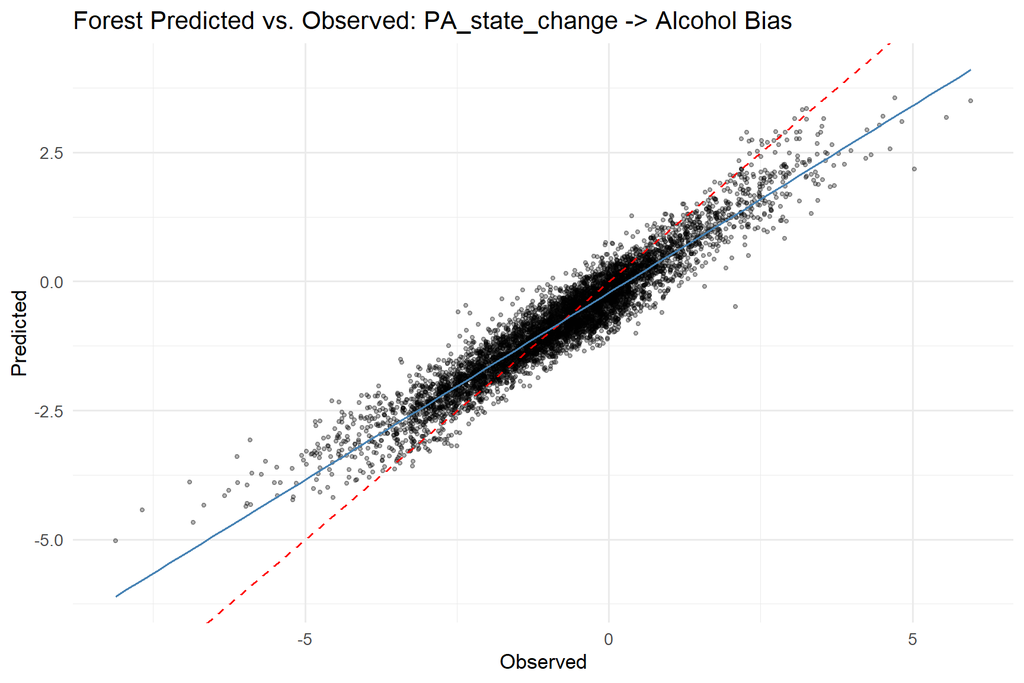

## 7.4 Model Comparison

### 7.4.1 RMSE Comparison (all methods and feature sets)

| Method | Raw | PCA | UMAP |
| --- | --- | --- | --- |
| glmm | 1.6965 | 1.7290 | 1.5805 |
| forest | 1.0544 | 1.2703 | 1.1843 |
| tree | 1.3463 | 1.4087 | 1.4106 |